# Introduction To R | Session 1

LMS Bioinformatics Facility

bioinformatics@lms.mrc.ac.uk

2023-10-18

## First things first

Get going by downloading and installing `R` and `RStudio` (in that order).

[figure not shown]

## Learning objectives

**Session 1**

- Introduction to `R` and `RStudio`
- Basic data types
- Functions
- Arithmetic and logical operators
- Vectors, data frames, and factors
- Indexing
- Reading data
- Plotting with base R

## RStudio

`RStudio` has a four panel layout: documents, console, environment, and *stuff* (plots, help, files, …)

[figure not shown]

- Set the working directory (`Session > Set Working Directory`) to the `working_area` folder
- Open a new document … `File > New File >`:
  - `R Notebook`: allows you to interleave `R` code, comments, and images. An HTML is automatically produced that records the last outputs when the document is saved
  - `R Markdown`: the same, but will an HTML is only produced when asked, and all code is re-run (*knit*) before it’s produced
- Commands run in the documents pane and in the console will behave identically. Run a line of code with `⌘+Enter` (Mac) or `CTRL+Enter` (Windows), or by typing it into the console directly.
- Run individual or highlighted lines of code with `⌘+Shift+Enter` (Mac) or `CTRL+Shift+Enter` (Windows)
- Insert a code block at the position of the cursor with `⌘+⌥+I` (Mac) or `CTRL+Alt+I` (Windows)
- Press the `⏵` (run) button to run a code block
- Press `⌘+S` (Mac) or `CTRL+S` (Windows) to save

## Assignment

Let’s try some basic calculations. `R` knows all the usual arithmetic operators: `+`, `-`, `/`, `*`, and `^`. By default, results are printed to the screen.

```r
1 + 1
```

```
## [1] 2
```

To store an answer, we must *assign* it with either the `<-` or `=` operator.

```r
a <- 10 / 2  # is the same ...
a = 10 / 2   # ... as this
```

Here, an *object* (or *variable*), `a`, is created to store the calculation’s result. We can query what `a` stores.

```r
a
```

```
## [1] 5
```

Assignment works from right to left. Here, we can say that `b` *becomes equal to* the result of `sqrt(25)`.

```r
b = sqrt(25)
b
```

```
## [1] 5
```

Stored objects appear in `RStudio`’s environment panel. As in algebra, they can be used in calculations.

```r
a * b
```

```
## [1] 25
```

Assigning to an existing object will overwrite its previous value.

```r
a = a * b
a
```

```
## [1] 25
```

## Comments

Comments in your code allow you to keep track of your ideas and to document your work. In `R`, on each line, everything after a `#` symbol is considered a comment and will not be run.

```r
# This whole line is a comment

a = a * b  # This is a comment as well!
```

We can highjack this system to ‘comment out’ code sections if we don’t want them to run.

```r
# The following calculation will not run:
# a = a * b
```

For the current or highlighted lines, the `⌘+Shift+C` (Mac) or `CTRL+Shift+C` (Windows) will comment and un-comment lines for you in `RStudio`.

## Object naming

As in all programming languages, in `R`, there are rules about what names an object can be given.

Object names *cannot* start with a number …

```r
1var = 1  # will fail
```

… contain special characters (e.g. a minus sign) …

```r
my-variable = 1  # will also fail
```

… or contain spaces.

```r
my variable = 1  # will also also fail
```

Object names can only contain, numbers, characters, underscores, and points.

Names should be short and meaningful so that you can type them easily and know what they store.

```r
tcga_data = ...  # a nice, short, meaningful name

the_data_we_got_from_that_2019_paper = ...  # not a good name!

t = ...  # tulip? turtle? time?
```

As spaces aren’t allowed, there are are two preferred options instead.

```r
this_is_called_snake_case = "hello"
```

```r
thisIsCalledCamelCase = "world"
```

## Functions

`sqrt()` was an example of a *function*. A function runs a pre-determined calculation or procedure, generally (but not always) returning an answer.

```r
one_to_ten = seq(1, 10)
one_to_ten
```

```
##  [1]  1  2  3  4  5  6  7  8  9 10
```

```r
min(one_to_ten)
```

```
## [1] 1
```

```r
max(one_to_ten)
```

```
## [1] 10
```

`R` is extremely well documented. To find out what a function does or how to use it, use the `?` operator.

```r
?mean
```

```
Arithmetic Mean

Description
  Generic function for the (trimmed) arithmetic mean.

Usage
  mean(x, ...)

## Default S3 method:
  mean(x, trim = 0, na.rm = FALSE, ...)

...
```

We can also ask `R` to give an example of the function in use … though some are a bit complicated!

```r
example("mean")
```

The full *function signature* for `mean()` is `mean(x, trim = 0, na.rm = FALSE, ...)`.

Breaking it down:

- the function name is `mean`
- inputs to the function - its *arguments* - are provided within the brackets
- *required* arguments do not have a preset value (e.g. `x`). They are generally *positional* so that, provided you pass them in the correct order, you don’t have to specify their names.

```r
mean(one_to_ten)  # is the same as ...
mean(x=one_to_tex)  # ... this. The names of positional arguments are implicit
```

- *optional* arguments have a preset value (e.g. `trim = 0`) and, if they’re not specified, the preset will be used. For clarity, when we do specify optional arguments, it’s good practice to use their names.

```r
mean(one_to_ten, trim=0.1)
```

## Practical

Ask `R` what these functions do:

- `mad`
- `ceiling`
- `floor`
- `toupper`
- `range`

## Basic data types

There are three *basic* data types that we use in `R` day-to-day:

- `Numeric` values (stored identically whether they have a floating point or not) store a number
- `Character` values (aka a *string* of characters) wrapped in quotation marks store text
- `Logical` values (aka a *boolean*) store a `TRUE/FALSE` result

The type of an object can be determined using the `class()` function.

```r
class(1)
```

```
## [1] "numeric"
```

```r
class("this is a string")
```

```
## [1] "character"
```

## Vectors

Basic data types can be grouped into collections of *elements*. A `vector` is one of the most fundamental, storing elements of the same type.

The `c()` function combines the given elements, flattening any other vectors along the way.

```r
c(1, 2, 3)
```

```
## [1] 1 2 3
```

```r
c("one", "two", "three", c("four", "five"))
```

```
## [1] "one"   "two"   "three" "four"  "five"
```

```r
c(TRUE, FALSE, T, F)
```

```
## [1]  TRUE FALSE  TRUE FALSE
```

There are a number of handy functions for creating vectors.

The `seq()` function (or the `:` operator) will create a sequence of numbers

```r
seq(1, 10)
```

```
##  [1]  1  2  3  4  5  6  7  8  9 10
```

```r
1:10
```

```
##  [1]  1  2  3  4  5  6  7  8  9 10
```

The `rep()` function will repeat a given object a specified number of times

```r
a = rep(1:5, 3)
a
```

```
##  [1] 1 2 3 4 5 1 2 3 4 5 1 2 3 4 5
```

## Practical

Let’s work out what these will do when making a vector:

- `seq(1, 10, 2)`
- `10:1`
- `c(1:10, 10:1)`

## R is vectorised

Many of the core `R` functions are *vectorised* - i.e. functions are written to operate on all elements of a vector simultaneously.

Vector operations avoid the need to loop through and act on each element individually, making writing code more concise and less error prone. They’re also much faster!

```r
a ^ 2
```

```
##  [1]  1  4  9 16 25  1  4  9 16 25  1  4  9 16 25
```

```r
log(a)
```

```
##  [1] 0.0000000 0.6931472 1.0986123 1.3862944 1.6094379 0.0000000 0.6931472
##  [8] 1.0986123 1.3862944 1.6094379 0.0000000 0.6931472 1.0986123 1.3862944
## [15] 1.6094379
```

## Indexing vectors

Specific elements can be extracted from vectors by their position (or *index*) using square brackets (`[ ]`).

```r
a[5]
```

```
## [1] 5
```

```r
a[1:3]
```

```
## [1] 1 2 3
```

Conversely, specific elements can be excluded by using a minus sign.

```r
a[-c(1, 3, 5)]
```

```
##  [1] 2 4 1 2 3 4 5 1 2 3 4 5
```

The order of index values matters - `[c(1, 2)]` is different to `[c(2, 1)]`. The order of the supplied index values can be used to arrange data, therefore.

```r
a[15:1]
```

```
##  [1] 5 4 3 2 1 5 4 3 2 1 5 4 3 2 1
```

`order()` sorts a vector and returns the index values in the order that achieve this representation.

```r
order(a)
```

```
##  [1]  1  6 11  2  7 12  3  8 13  4  9 14  5 10 15
```

```r
a[order(a)]
```

```
##  [1] 1 1 1 2 2 2 3 3 3 4 4 4 5 5 5
```

Name-based indexing of vectors is also possible.

Names can be assigned to an existing vector by using the `names()` function.

```r
a = c(1, 2, 3)
names(a) = c("first", "second", "third")
a
```

```
##  first second  third
##      1      2      3
```

Alternatively, names can be supplied when the vector is first created.

```r
a = c(first=1, second=2, third=3)
a
```

```
##  first second  third
##      1      2      3
```

Named vectors can be indexed using square brackets (`[ ]`) (to retain the names) or with double square brackets (`[[ ]]`) (to discard them).

```r
a["second"]
```

```
## second
##      2
```

```r
a[["second"]]
```

```
## [1] 2
```

Indexing does not work beyond the bounds of a vector, however - you can’t index beyond its length

```r
length(a)
```

```
## [1] 3
```

```r
a[4]
```

```
## <NA>
##   NA
```

Here, `R` uses the `NA` (not available) logical constant to signify that a value is missing.

Similarly, you can’t index a named vector with a name that it does not contain.

```r
names(a)
```

```
## [1] "first"  "second" "third"
```

```r
a["fourth"]
```

```
## <NA>
##   NA
```

Again, `R` uses the `NA` (not available) logical constant to signify that a value is missing.

## Practical

You have inherited 4 penguins from an estranged aunt!

- Make a vector that records their ages in months: 15, 53, 97, and 64.
- Have you chosen a good name?
- Add the information that their names are Basil, Tim, Lisa, and Snapper.
- What are their ages in complete years?
- What is the median age of your penguins?

## Index-based replacement

Specific elements within vectors can be replaced by referencing their index in an assignment operation. This works identically for position-based and name-based indexing.

```r
a[1:2] = 0
a
```

```
##  first second  third
##      0      0      3
```

```r
a[c("first", "second")] = c(1, 2)
a
```

```
##  first second  third
##      1      2      3
```

## Logical operations

Two objects can be compared to one another using *logical operations*:

- `x == y` … is equal to
- `x != y` … is not equal to
- `x > y` … is greater than (`>=` or equal to)
- `x < y` … is less than (`<=` or equal to)

These return a logical `TRUE/FALSE` answer.

```r
1 > 2
```

```
## [1] FALSE
```

## Logical operations on vectors

Logical operators are vectorised in `R`; when run on a vector, they return a logical vector of the same length …

```r
a <= 2
```

```
##  first second  third
##   TRUE   TRUE  FALSE
```

… which can be used to subset the original vector.

```r
a[a <= 2]
```

```
##  first second
##      1      2
```

Asking whether a variable is contained within a vector is an example of a *set membership query* and can be performed using the `%in%` operator. As with other logical operators, these are vectorised in `R` …

```r
b = c(3, 4, 5)
a %in% b
```

```
## [1] FALSE FALSE  TRUE
```

… and can be used for subsetting.

```r
a[a %in% b]
```

```
## third
##     3
```

As stated, when run on a vector, these operations return a logical vector of the same length.

If it’s preferable to just have a list of the indices that satisfy a given logical criteria, the `which()` function can be used instead …

```r
which(a %in% b)
```

```
## [1] 3
```

… which can be used to subset the original vector in exactly the same way.

```r
a[which(a %in% b)]
```

```
## third
##     3
```

## Modifying logicals

Single logical variables or vectors of them can be combined and manipulated with the `&` (and), `|` (or), and `!` (not) operators.

```r
TRUE & FALSE  # do both objects evaluate to TRUE?
```

```
## [1] FALSE
```

```r
c(TRUE, FALSE, FALSE) | c(TRUE, TRUE, FALSE)  # in pairs, does either evaluate to TRUE?
```

```
## [1]  TRUE  TRUE FALSE
```

```r
!(1 > 2)  # the `not` operator inverts the answer
```

```
## [1] TRUE
```

## Practical

Many Emperor penguins don’t start breeding until they’re 6 years old.

- Which of penguins are too young to breed?

To bump up your numbers, you decide to get more penguins.

- Update your vector to add Erica (99) and Jen (107)

## Reading data into vectors

Vectors can be created from simple text files by using the `scan(file, what)` function. We pass two important arguments:

- `file` … the location of the file to be read
- `what` … the basic data type that it contains: character, numeric, or logical

```r
my_first_data = scan("data/1_scan.txt", "character")
my_first_data
```

```
## [1] "Wow"  "that" "was"  "very" "easy"
```

## Data frames

The `data.frame()` function can be used to combine individual vectors into columns of a unified table.

Separate columns can be used to store different data types but each column is still an individual vector … and vectors can only store a single data type.

```r
df = data.frame(col1=c(1, 2, 3), col2=c("one", "two", "three"))
df
```

```
##   col1  col2
## 1    1   one
## 2    2   two
## 3    3 three
```

```r
class(df)
```

```
## [1] "data.frame"
```

As data frames are two dimensional, different functions are required to manipulate them.

Columns can be added using `cbind()` (column bind) …

```r
df = cbind(df, col3=c(TRUE, FALSE, TRUE))
df
```

```
##   col1  col2  col3
## 1    1   one  TRUE
## 2    2   two FALSE
## 3    3 three  TRUE
```

… or using the special `$` operator.

```r
df$col4 = c(1.1, 1.2, 1.3)
df
```

```
##   col1  col2  col3 col4
## 1    1   one  TRUE  1.1
## 2    2   two FALSE  1.2
## 3    3 three  TRUE  1.3
```

Similarly, instead of `names()`, there are `rownames()` …

```r
rownames(df) = c("a", "b", "c")
df
```

```
##   col1  col2  col3 col4
## a    1   one  TRUE  1.1
## b    2   two FALSE  1.2
## c    3 three  TRUE  1.3
```

… and `colnames()`.

```r
colnames(df) = toupper(colnames(df))
df
```

```
##   COL1  COL2  COL3 COL4
## a    1   one  TRUE  1.1
## b    2   two FALSE  1.2
## c    3 three  TRUE  1.3
```

In a data frame, column and row names must be unique. Duplicate names are not allowed!

Instead of `length()`, to get the size of a data frame, we can use `nrow()` …

```r
nrow(df)
```

```
## [1] 3
```

… `ncol()` …

```r
ncol(df)
```

```
## [1] 4
```

… or, to get both together, `dim()`.

```r
dim(df)
```

```
## [1] 3 4
```

## Indexing data frames

To access the information within a data frame, as with vectors, we use square brackets (`[ ]`). However, we must now define both row and column positions:

- `[r, ]` … index values before the comma refer to rows
- `[, c]` … index values after the comma refer to columns
- Omitting either one, as above, will return all possibilities.

```r
df[2, ]
```

```
##   COL1 COL2  COL3 COL4
## b    2  two FALSE  1.2
```

```r
df[, 2]
```

```
## [1] "one"   "two"   "three"
```

As with named vectors, we can also index by row and column name …

```r
df[c("a", "b"), ]
```

```
##   COL1 COL2  COL3 COL4
## a    1  one  TRUE  1.1
## b    2  two FALSE  1.2
```

```r
df[, "COL1"]
```

```
## [1] 1 2 3
```

… and we can access columns individually with the `$` operator, which returns the underlying vector.

```r
df$COL1
```

```
## [1] 1 2 3
```

## Reading data into data frames

Tabular plain-text formats can be exported from most software. In `Excel` it’s easy to export data as either tab-separated (`.tsv` / `.txt`) or as comma-separated (`.csv`) files directly when saving a document.

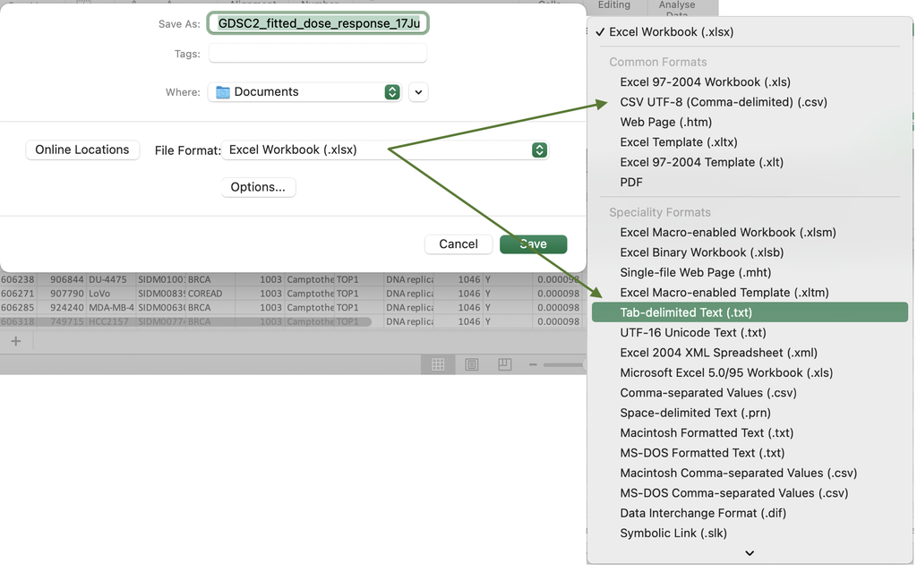

Tab-separated and comma-separated data can be imported using the `read.delim()` and `read.csv()` functions, respectively.

```r
df = read.delim("data/1_read_delim.txt")
```

Data frames can be very large and cumbersome to view. To make things easier, we can use:

- `head()` to display the first few rows
- `tail()` to display the last few rows
- `view()`, which in `RStudio` will open a separate tab to display the contents
- `str()` to view its structure and the basic types of its component vectors
- `table()` and `summmary()` to view compact representations of columns

```r
head(df)
```

```
##   ID    Name Sex Age HatColour
## 1 E1   Basil   M  15      blue
## 2 E2     Tim   M  53       red
## 3 E3    Lisa   F  97    yellow
## 4 E4 Snapper   M  64     green
## 5 E5   Erica   F  99    yellow
## 6 E6     Jen   F 107       red
```

```r
str(df)
```

```
## 'data.frame':    10 obs. of  5 variables:
##  $ ID       : chr  "E1" "E2" "E3" "E4" ...
##  $ Name     : chr  "Basil" "Tim" "Lisa" "Snapper" ...
##  $ Sex      : chr  "M" "M" "F" "M" ...
##  $ Age      : int  15 53 97 64 99 107 60 150 131 78
##  $ HatColour: chr  "blue" "red" "yellow" "green" ...
```

## Merging data frames

Often, we need to merge data frames that have been stored separately. The `merge()` function will automate merger by matching up values from two tables based on a specified (*key*) column.

```r
df2 = read.delim("data/1_read_delim_merge.txt")
colnames(df2)
```

```
## [1] "ID"     "Height" "Weight"
```

```r
penguins = merge(df, df2, by="ID")
head(penguins)
```

```
##   ID    Name Sex Age HatColour Height Weight
## 1 E1   Basil   M  15      blue    120   35.6
## 2 E2     Tim   M  53       red    115   33.2
## 3 E3    Lisa   F  97    yellow    125   37.3
## 4 E4 Snapper   M  64     green    127   38.0
## 5 E5   Erica   F  99    yellow    110   30.1
## 6 E6     Jen   F 107       red    119   36.5
```

## Practical

So, you’ve started to record things about your penguins. We’re not judging.

- How many penguins do you now have?
- Are you sure? What happens if you merge the data frames with `merge(..., all=TRUE)`?
- Why is this different?
- What are the average ages of the female and, separately, of the male penguins?
- What function might we use to work out a unique list of the different hat colours they have?
- How could we change the order of the rows if we wanted to arrange by age?
- What does `table(penguins$HatColour)` do? How about `table(penguins$Sex, penguins$HatColour)`?

## NA values

Data frames and vectors containing `NA` values can require special treatment when running functions or calculations.

```r
penguins = merge(df, df2, by="ID", all=TRUE)
range(penguins$Height)
```

```
## [1] NA NA
```

We can *sanitise* an entire data frame by using the `na.omit()` function to drop `NA`-containing rows …

```r
penguins = na.omit(penguins)
```

… but, unless we want to discard data, it’s often better to just drop `NA`s from vectors during calculations.

```r
range(na.omit(penguins$Height))
```

```
## [1] 110 130
```

## Factors

Where vectors store *categorical* data, we can convert them to a special `factor` class, which allows their use with specialised functions.

A factor is suitable where we might logically group the rows by it:

- `Sex` can be grouped … it’s a factor
- `Age` is a continuous spread … it’s not a factor
- `ID` is a unique identifier for each row, there’s probably no advantage to it being a factor

Further, there are two subclasses of factors:

- nominal factors are inherently unordered (e.g. `Sex`)
- ordinal factors are inherently ordered (e.g. timepoint)

Factors can be created using the `factor()` function on a vector …

```r
penguins$Sex = factor(penguins$Sex)
penguins$Sex
```

[output not shown]

```r
class(penguins$Sex)
```

```
## [1] "factor"
```

… and its *levels* can be viewed.

```r
levels(penguins$Sex)
```

```
## [1] "F" "M"
```

## Ordering factors

The ordering of factor levels is important, as the first is taken as the *reference*. By default, levels are sorted numerically or lexicographically.

For nominal factors, this can be controlled by specifying either a different reference level …

```r
relevel(penguins$Sex, "M")
```

```
##  [1] M F M F M F F M M F
## Levels: M F
```

… or by re-applying the `factor()` function and providing a different order.

```r
factor(penguins$Sex, levels=c("M", "F"))
```

```
##  [1] M F M F M F F M M F
## Levels: M F
```

For ordinal factors, this is controlled by re-applying the function with `factor(..., ordered=TRUE)`.

```r
timepoint = factor(c("d0", "d1", "d3", "d7", "d10"))
timepoint
```

```
## [1] d0  d1  d3  d7  d10
## Levels: d0 d1 d10 d3 d7
```

```r
timepoint = factor(
  timepoint,
  levels=c("d0", "d1", "d3", "d7", "d10"),
  ordered=TRUE)
timepoint
```

```
## [1] d0  d1  d3  d7  d10
## Levels: d0 < d1 < d3 < d7 < d10
```

```r
is.ordered(timepoint)
```

```
## [1] TRUE
```

## Modifying factors

The level of an element can be switched (provided the replacement level is already defined) in the same way a vector is modified.

```r
timepoint[1] = "d3"
timepoint
```

```
## [1] d3  d1  d3  d7  d10
## Levels: d0 < d1 < d3 < d7 < d10
```

The `levels()` function can also be used to rename levels en masse and adjust the elements correspondingly.

```r
levels(timepoint) = c("day0", "day1", "day3", "day7", "day10")
timepoint
```

```
## [1] day3  day1  day3  day7  day10
## Levels: day0 < day1 < day3 < day7 < day10
```

However, to change an individual element to a previously undefined level, it must be added first.

```r
levels(timepoint) = c("day0", "day1", "day3", "day7", "day10", "day14")
timepoint[1] = "day14"
timepoint
```

```
## [1] day14 day1  day3  day7  day10
## Levels: day0 < day1 < day3 < day7 < day10 < day14
```

If, as a result of modification or subsetting, levels become unused, they can be removed using the `droplevels()` function.

```r
timepoint = droplevels(timepoint)
timepoint
```

```
## [1] day14 day1  day3  day7  day10
## Levels: day1 < day3 < day7 < day10 < day14
```

## Practical

- Update the `penguins` data frame to make this change.
- Is `HatColour` nominal or ordinal?
- Penguin `E1` (Basil) does not like having a `blue` hat and would prefer `red`. What steps do we need to take to fully update our data frame?

## Plotting in base R

We will cover plotting in more detail using the `ggplot2` library in **Session 4**. ‘Base’ `R` can still do some basic plotting, though, and has four types of graph built in:

- `plot()` produces scatter plots
- `boxplot()`
- `barplot()`
- `histogram()`

As with other functions, we can find out how to use these functions with the `?` operator.

```r
?boxplot
```

`boxplot` expects a formula (of the form `y ~ x`) as its single positional argument and we can pass a data frame to it using the `data` optional argument.

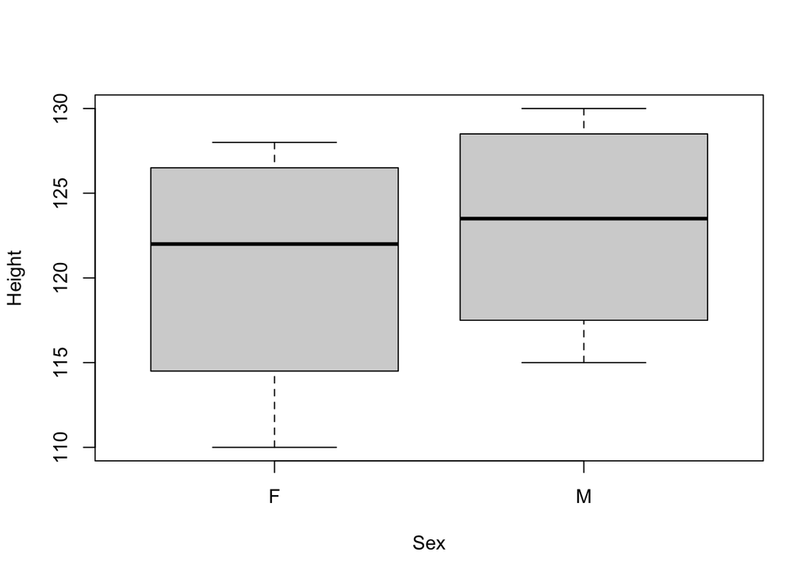

```r
boxplot(Height~Sex, data=penguins)
```

`plot`, somewhat cryptically, says “any reasonable way of defining the coordinates is acceptable” when describing its input format. Sufficed to say that one reasonable way is to use a formula and `data`, as we did for the `boxplot`.

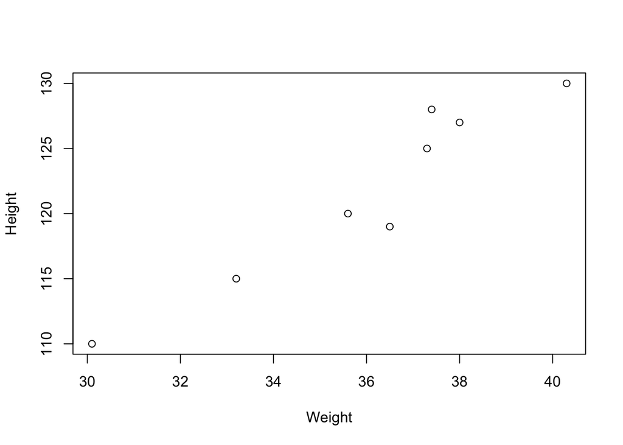

```r
plot(Height~Weight, data=na.omit(penguins))
```

Columns defined as factors can be used to modify the aesthetics of the plot. For example, we can edit the colour and shape of points based on `Sex`. It makes sense to then also use the `legend()` function to show what we’ve done.

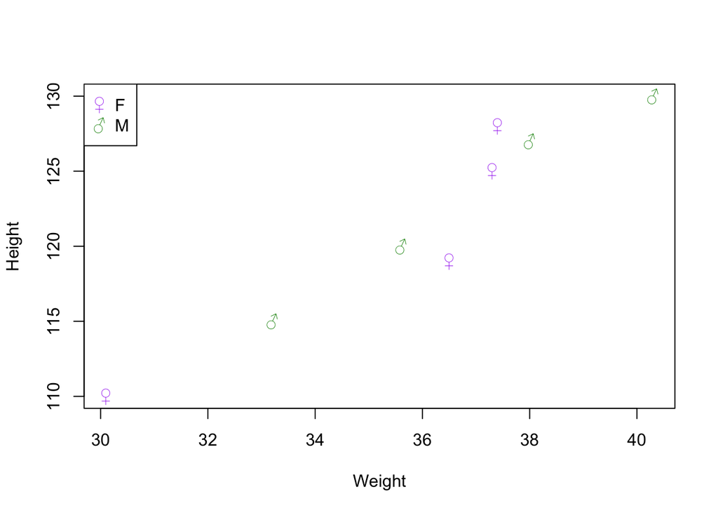

```r
plot(Height~Weight, data=na.omit(penguins), col=c("purple", "green4")[Sex], pch=c("♀", "♂")[Sex])
legend("topleft", legend=levels(penguins$Sex), col=c("purple", "green4"), pch=c("♀", "♂"))
```

## Homework

There are some penguin-related homework tasks to help cement what we’ve covered today!

The homework and instructions can be found within the main directory for the course: `./homework/Homework_1.Rmd`